# Assignment 2

Edwin Ngungi

2026-03-04

# Question 1

## 1a. Use the descriptives file to assign labels/categories to all the categorical variables in the data.

```r
# Load datasets

data <- read.csv("C:/Users/engungi/OneDrive - Retirement Benefit Authority/Desktop/Classes/Masters/Yr1 Sem 2/STA 8204 - Computational Statistics/STAT_8202_Computational-Statistics/Data/contraceptive_data.csv")

# 1a. Assign labels to categorical variables
data$wife_edu <- factor(data$wife_edu, levels = 1:4, labels = c("Low", "Level 2", "Level 3", "High"))
data$hus_edu  <- factor(data$hus_edu, levels = 1:4, labels = c("Low", "Level 2", "Level 3", "High"))
data$num_child <- factor(data$num_child, levels = 1:4, labels = c("0", "1-2", "3-4", "5+"))
data$wife_rel <- factor(data$wife_rel, levels = 0:1, labels = c("Non-Islam", "Islam"))
data$con_method <- factor(data$con_method, levels = 1:3, labels = c("No-use", "Long-term", "Short-term"))
print(head(data))
```

```
##   X wife_age wife_edu hus_edu num_child wife_rel wife_work hus_occup live_index
## 1 1       24  Level 2 Level 3       3-4    Islam         1         2          3
## 2 2       45      Low Level 3      <NA>    Islam         1         3          4
## 3 3       43  Level 2 Level 3      <NA>    Islam         1         3          4
## 4 4       42  Level 3 Level 2      <NA>    Islam         1         3          3
## 5 5       36  Level 3 Level 3      <NA>    Islam         1         3          2
## 6 6       19     High    High      <NA>    Islam         1         3          3
##   media_exp con_method
## 1         0     No-use
## 2         0     No-use
## 3         0     No-use
## 4         0     No-use
## 5         0     No-use
## 6         0     No-use
```

## 1.b Between wives and husbands, who are more educated?

```r
wife_edu_pct <- prop.table(table(data$wife_edu)) * 100
husb_edu_pct <- prop.table(table(data$hus_edu)) * 100

# Print results rounded to 2 decimal places for neatness
print("Wife Education Levels (%):")
```

```
## [1] "Wife Education Levels (%):"
```

```r
round(wife_edu_pct, 2)
```

```
##
##     Low Level 2 Level 3    High
##   10.32   22.67   27.83   39.17
```

```r
print("Husband Education Levels (%):")
```

```
## [1] "Husband Education Levels (%):"
```

```r
round(husb_edu_pct, 2)
```

```
##
##     Low Level 2 Level 3    High
##    2.99   12.08   23.90   61.03
```

Husbands are more educated the wives, a higher percentage are highly educated while a lower percentage have a lower level of education.

## 1.c How many women have given birth to more than 4 children?

```r
count_gt4 <- sum(data$num_child == "5+", na.rm = TRUE)
print(paste("Number of women with > 4 children:", count_gt4))
```

```
## [1] "Number of women with > 4 children: 197"
```

## 1d. Describe the distribution of wife’s age

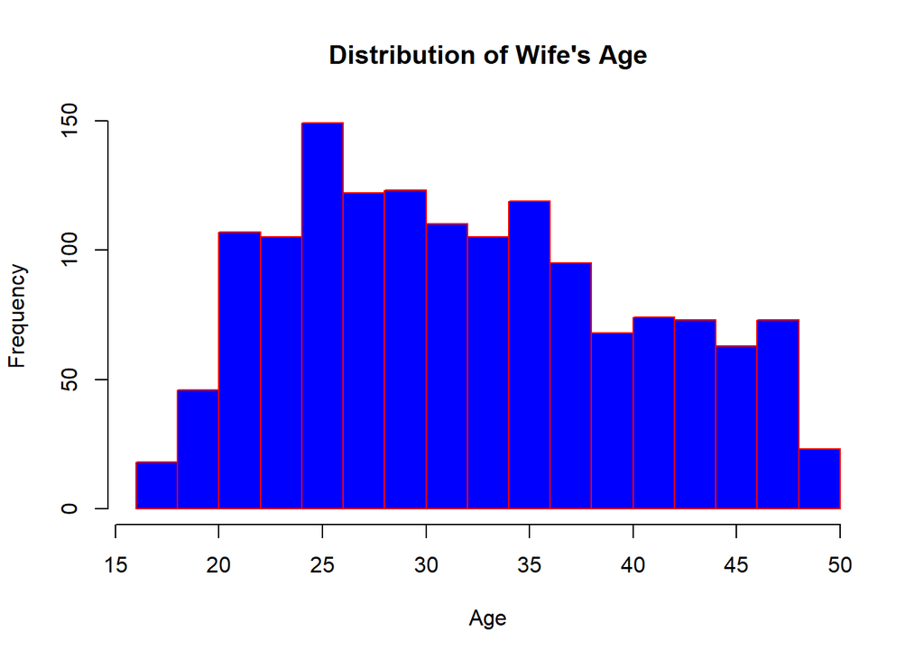

```r
hist(data$wife_age, col="blue", main="Distribution of Wife's Age",
     xlab="Age", border="red")
```

The distribution of wives’ ages is right‑skewed (positively skewed), with most women concentrated in the mid‑20s to early 30s.

## 1e. show and comment on the relationship of contraceptive usage

and religion.

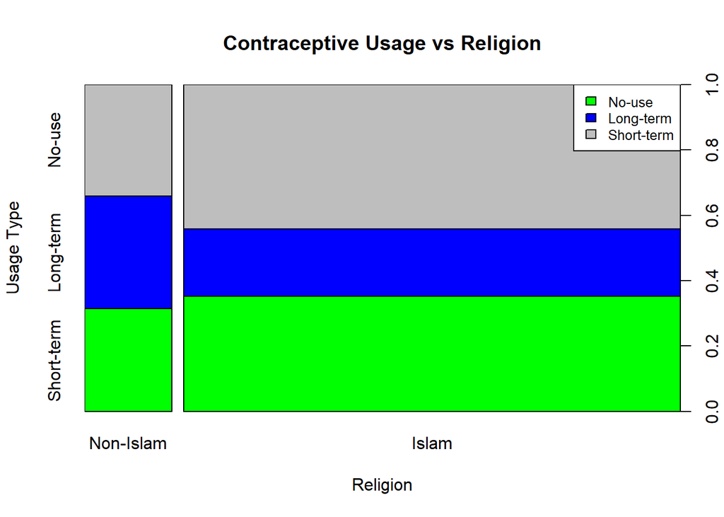

```r
# Plot the mosaic with specific colors
plot(data$wife_rel, data$con_method,
     main="Contraceptive Usage vs Religion",
     xlab="Religion", ylab="Usage Type",
     col=c("green", "blue", "gray"))

# Add a legend to define the colors clearly
legend("topright",
       legend = c("No-use", "Long-term", "Short-term"),
       fill = c("green", "blue", "gray"),
       cex = 0.8)
```

Non-Islam women seem to prefer more long term use of contraceptives compared to Islam women who are show a higher rate of no usage and short-term forms of contraceptives.

## 1f. What is the median age of using short-term contraceptive methods? How does this compare to those who have never used contraceptives?

```r
median_short <- median(data$wife_age[data$con_method == "Short-term"])
median_none <- median(data$wife_age[data$con_method == "No-use"])
print(paste("Median Age (Short-term):", median_short))
```

```
## [1] "Median Age (Short-term): 29"
```

```r
print(paste("Median Age (No-use):", median_none))
```

```
## [1] "Median Age (No-use): 32"
```

## 1g. Add any additional visualization to explore the data.

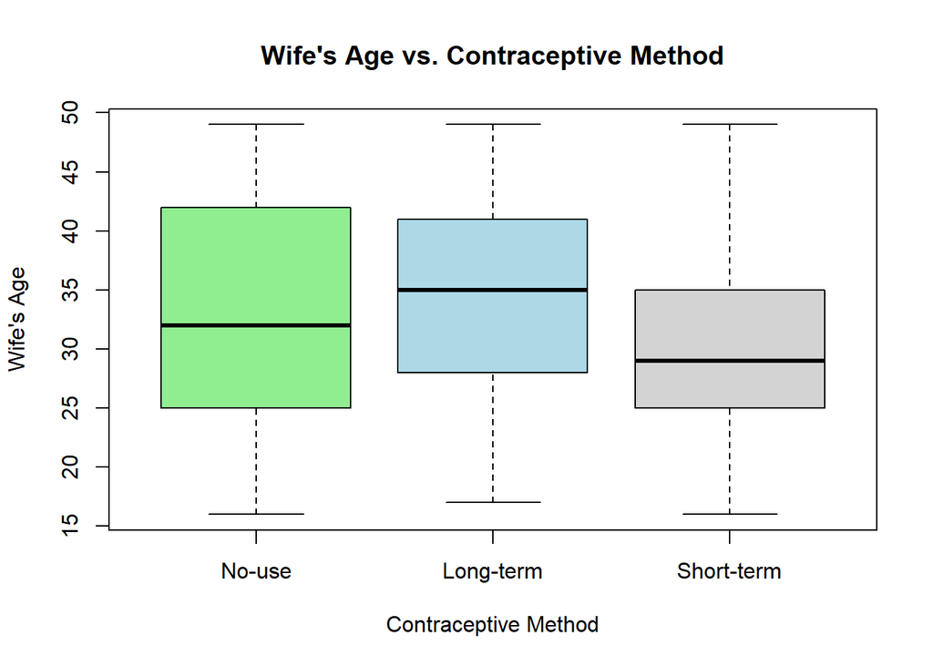

```r
# Boxplot to see age distribution across contraceptive methods
boxplot(data$wife_age ~ data$con_method,
        main="Wife's Age vs. Contraceptive Method",
        xlab="Contraceptive Method",
        ylab="Wife's Age",
        col=c("lightgreen", "lightblue", "lightgray"))
```

The chart suggests that younger women prefer short-term options, while older women tend to opt for long-term contraceptive solutions.

# Question 2: Calculate the empirical CDF of the number of children

```r
counts <- table(data$num_child)
probs <- prop.table(counts)
cum_probs <- cumsum(probs)

# --- Step 2: Inverse Transform Function ---
inverse_transform <- function(n_samples, cumulative_distribution) {
  # Generate n uniform random numbers
  u <- runif(n_samples)

  # Map U to the categories based on cum_probs
  # findInterval returns the index where U falls in the CDF steps
  samples <- findInterval(u, c(0, cumulative_distribution), all.inside = TRUE)
  return(samples)
}

# --- Step 3: Generate Samples ---
set.seed(453)
n <- nrow(data)
simulated_data <- inverse_transform(n, cum_probs)

# --- Step 4: Comparison ---
original_props <- probs
simulated_props <- prop.table(table(simulated_data))

print("Original Data Proportions:")
```

```
## [1] "Original Data Proportions:"
```

```r
print(original_props)
```

```
##
##         0       1-2       3-4        5+
## 0.2738095 0.2738095 0.2569444 0.1954365
```

```r
print("Simulated Data Proportions:")
```

```
## [1] "Simulated Data Proportions:"
```

```r
print(simulated_props)
```

```
## simulated_data
##         1         2         3         4
## 0.2620502 0.2539036 0.2715547 0.2124915
```

The simulated percentages are very close to the original data proportions. This indicates that the Inverse Transform Method was successful in replicating the distribution of the original dataset

# Question 3, Monte Carlo Estimation

## 3a.

```r
# 1. Define the number of MC simulations
m <- 10000
set.seed(123)

# 2. Generate samples using the Empirical Distribution
mc_samples <- inverse_transform(m, cum_probs)

# 3. Apply the indicator function: 1 if category is 3, else 0
hits <- ifelse(mc_samples == 3, 1, 0)

# 4. Calculate the MC Estimate (Mean of indicators)
theta_hat <- mean(hits)

# 5. Calculate True Proportion from original data for comparison
true_prop <- prop.table(table(data$num_child))["3-4"]

print(paste("Monte Carlo Estimate:", round(theta_hat, 4)))
```

```
## [1] "Monte Carlo Estimate: 0.2581"
```

```r
print(paste("True Proportion:", round(true_prop, 4)))
```

```
## [1] "True Proportion: 0.2569"
```

The Monte Carlo estimate of 0.2581 is nearly identical to the true proportion of 0.2569, meaning that the simulation successfully replicated the original data distribution.

## 3b.

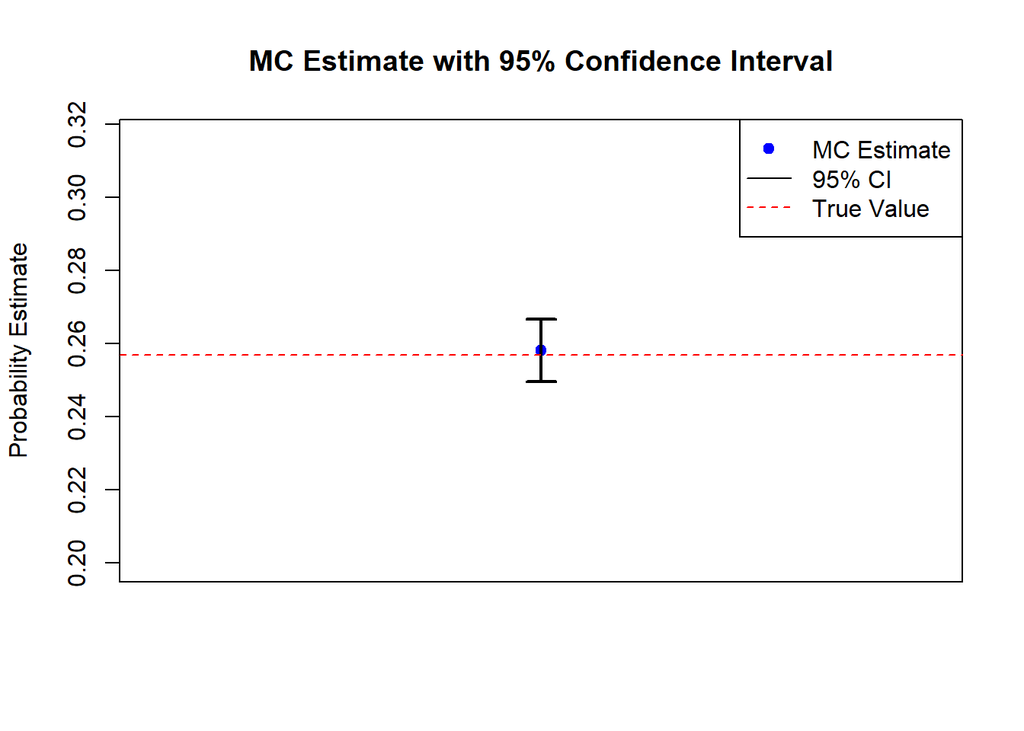

```r
# 1. Standard Error calculation
se <- sqrt((theta_hat * (1 - theta_hat)) / m)

# 2. 95% CI bounds
ci_lower <- theta_hat - (1.96 * se)
ci_upper <- theta_hat + (1.96 * se)

# 3. Plotting
plot(1, theta_hat, ylim=c(ci_lower - 0.05, ci_upper + 0.05), xlim=c(0, 2),
     main="MC Estimate with 95% Confidence Interval",
     xlab="", ylab="Probability Estimate", xaxt='n', pch=19, col="blue")
arrows(1, ci_lower, 1, ci_upper, angle=90, code=3, length=0.1, lwd=2)
abline(h=true_prop, col="red", lty=2) # True value line
legend("topright", legend=c("MC Estimate", "95% CI", "True Value"),
       col=c("blue", "black", "red"), pch=c(19, NA, NA), lty=c(NA, 1, 2))
```

Since the true value falls within the black error bars (95% confidence interval), the results are statistically reliable and the estimation method is successful.

# Question 4

## 4a. Find the maximum reproductive age of a woman.

```r
# Coefficients from the equation y = -2.6 + 0.2x - 0.0008x^2
a_coeff <- -0.0008
b_coeff <- 0.2
max_reproductive_age <- -b_coeff / (2 * a_coeff)

# Display the result
print(max_reproductive_age)
```

```
## [1] 125
```

The maximum reproductive age of a woman as per the equation is 125 years.

## 4b. Compute the average number of children for a woman in a specific age.

```r
# Define the function
f_children <- function(x) { -2.6 + 0.2*x - 0.0008*x^2 }

# Select specific ages to showcase the results
milestone_ages <- c(20, 25, 30, 35, 40, 45, 50)

# Compute averages
avg_values <- f_children(milestone_ages)

# Create and print a simple table
results_table <- data.frame(Age = milestone_ages,
                            Average_Children = round(avg_values, 2))
print(results_table)
```

```
##   Age Average_Children
## 1  20             1.08
## 2  25             1.90
## 3  30             2.68
## 4  35             3.42
## 5  40             4.12
## 6  45             4.78
## 7  50             5.40
```

## 4c. Plot the values obtained in (b) against age of the women. Add a dotted line on the plot to show the value obtained in (a).

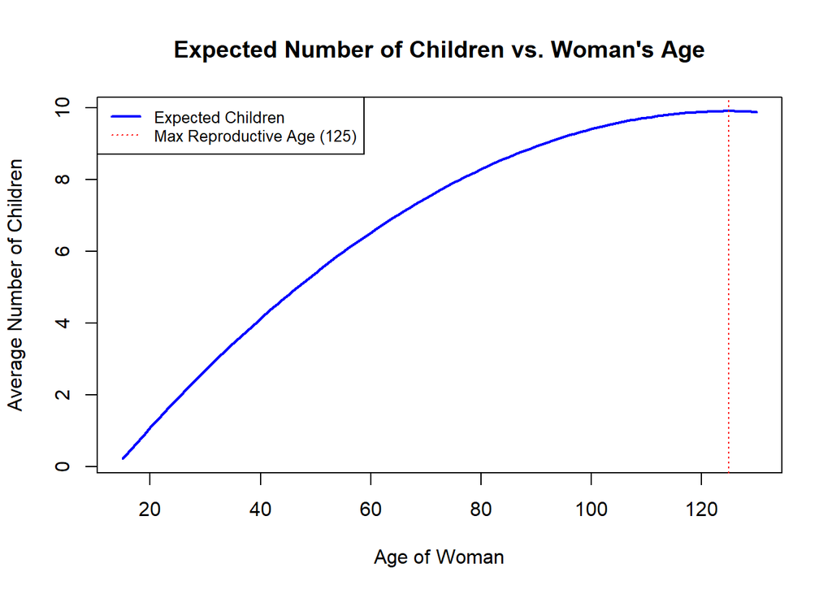

```r
# Create the plot
# 1. Define the function and age range
f_children <- function(x) { -2.6 + 0.2*x - 0.0008*x^2 }
plot_ages <- seq(15, 130, by = 1)
expected_y <- f_children(plot_ages)

# 2. Define the theoretical maximum age found in (a)
max_age_val <- 125

plot(plot_ages, expected_y, type = "l", col = "blue", lwd = 2,
     main = "Expected Number of Children vs. Woman's Age",
     xlab = "Age of Woman", ylab = "Average Number of Children")

# 4. Add the dotted vertical line for the maximum reproductive age
abline(v = max_age_val, col = "red", lty = 3)

# 5. Add a legend or label to explain the red line
legend("topleft", legend = c("Expected Children", "Max Reproductive Age (125)"),
       col = c("blue", "red"), lty = c(1, 3), lwd = c(2, 1), cex = 0.8)
```

# Question 5

## Question 5a. State the formula for estimating the probability of a woman ever used a contraceptive givenher education and number of children.

The probability $\pi_i$ that a woman has “ever used” a contraceptive, given her education ($x_1$) and number of children ($x_2$), is defined by the logistic function:
$$\pi_i = P(y_i=1 | x_{i1}, x_{i2})
= \frac{1}{1 + e^{-(\beta_0 + \beta_1 x_{i1} + \beta_2
x_{i2})}}$$
In logit form, this is expressed as:
$$\ln\left(\frac{\pi_i}{1 - \pi_i}\right) = \beta_0
+ \beta_1 x_{i1} + \beta_2 x_{i2}$$

## b. Derivation of the Likelihood Function

Since the outcome is binary, we assume $y_i$ follows a Bernoulli distribution. The likelihood function $L(\beta)$ for $n$ observations is the product of these individual probabilities:
$$L(\beta) =
\prod_{i=1}^{n} \pi_i^{y_i} (1 - \pi_i)^{1-y_i}$$
To simplify the optimization, we use the Log-Likelihood ($l(\beta)$):
$$l(\beta) = \sum_{i=1}^{n} [y_i \ln(\pi_i) +
(1-y_i) \ln(1-\pi_i)]$$

## c. Newton-Raphson Update Step

The Newton-Raphson method is an iterative algorithm used to find the maximum of the log-likelihood function. The update expression is:
$$\beta^{(k+1)} = \beta^{(k)} -
\mathbf{H}(\beta^{(k)})^{-1} \nabla l(\beta^{(k)})$$
Where:$\beta^{(k)}$ is the vector of coefficients at iteration $k$.$\nabla l(\beta)$ is the Gradient (vector of first derivatives).$\mathbf{H}(\beta)$ is the Hessian (matrix of second derivatives), which in logistic regression is $-X^T W X$, where $W$ is a diagonal matrix of weights $\pi_i(1-\pi_i)$.

## 5d: Implementation of the Newton-Raphson update step

```r
# Prepare binary outcome: 1 if Ever-used, 0 if No-use
data$ever_used <- ifelse(data$con_method == "No-use", 0, 1)

# Fit the logistic regression model
# Treating education and children as numeric for the regression
logit_model <- glm(ever_used ~ as.numeric(wife_edu) + as.numeric(num_child),
                   data = data,
                   family = binomial(link = "logit"))
summary(logit_model)
```

```
##
## Call:
## glm(formula = ever_used ~ as.numeric(wife_edu) + as.numeric(num_child),
##     family = binomial(link = "logit"), data = data)
##
## Coefficients:
##                       Estimate Std. Error z value Pr(>|z|)
## (Intercept)           -2.24042    0.28817  -7.775 7.56e-15 ***
## as.numeric(wife_edu)   0.56741    0.07153   7.932 2.15e-15 ***
## as.numeric(num_child)  0.43220    0.06539   6.609 3.86e-11 ***
## ---
## Signif. codes:  0 '***' 0.001 '**' 0.01 '*' 0.05 '.' 0.1 ' ' 1
##
## (Dispersion parameter for binomial family taken to be 1)
##
##     Null deviance: 1339.7  on 1007  degrees of freedom
## Residual deviance: 1234.8  on 1005  degrees of freedom
##   (465 observations deleted due to missingness)
## AIC: 1240.8
##
## Number of Fisher Scoring iterations: 4
```

## 5e. Comment on Logistic Regression Results

The model shows that both wife’s education and the number of children are significant predictors of contraceptive adoption, as indicated by the very small p-values. The positive coefficients (0.57 for education and 0.43 for number of children) mean that as a woman’s education level or number of children increases, the probability of her having ever used contraceptives also increases.

# Question 6

## 6a. Why Newton-Raphson and Golden Search Fail

The main reason these methods don’t work here is because of the absolute value ($|\beta_i|$) in the penalty part of the formula.Newton-Raphson needs to calculate “slopes” (derivatives) to find the best answer. But an absolute value has a sharp “V” shape at zero, and you can’t calculate a slope at a sharp corner.Golden Search is designed for much simpler problems with only one variable, whereas this model is trying to solve for many variables at once.

## Other Optimization Methods

Since the standard ways fail, we use methods that can handle those sharp corners, such as:

Coordinate Descent: This looks at one variable at a time to find the best fit.

Proximal Gradient Methods: These are specifically designed to “jump over” the corners that trip up Newton-Raphson.

### 6b. The Meaning of $\lambda$ and $\alpha$

$\lambda$ (Lambda): This controls the overall “penalty.” If it’s high, the model stays simple and avoids overfitting. If it’s low, the model is more complex.

$\alpha$ (Alpha): This decides the type of penalty.If $\alpha$ is 1, it’s like a Lasso, which can turn off unnecessary variables completely (setting them to zero).If $\alpha$ is 0, it’s like Ridge, which keeps all variables but makes them very small.